# RRR - Replicating Resampling with Rsampling

## Structural zeros

Some data sets have observations with zero frequency that are considered impossible to occur or be observed. Obvious cases are a cross table of gender and diseases where records of women with prostate cancer is zero. A less obvious example is in the *dataframe* `pielou`, which has the number of records of ten aphid species in twelve species of plants of the genus *Solidago* sites across Canada.

```r
> pielou
                  canadensis nemoralis rugosa juncea gigantea hispida
nigrotuberculatus         55        11     19     13        5       1
nigrotibius                9        39      4      5        3       3
caligatus                 24         6     22      1        4       0
pieloui                    8         1     11      9        8       9
canadensis                 8         5      2      5        0       4
gravicornis                8         4      2      5        4       0
lanceolatus                3         2      3      1        1       0
macgillivrayae             0         1      0      1        0       0
erigeronensis              2         0      0      0        0       0
solirostratus              0         0      0      0        0       0
                  squarrosa graminifolia caesia uliginosa flexicaulis
nigrotuberculatus         2            1      1         0           0
nigrotibius               0            0      2         4           1
caligatus                 0            1      0         0           0
pieloui                   4            4      1         1           0
canadensis                2            0      0         0           0
gravicornis               1            0      0         0           0
lanceolatus               0            0      1         0           0
macgillivrayae            0            2      0         0           0
erigeronensis             0            1      0         0           0
solirostratus             0            0      0         0           1
                  ohioensis
nigrotuberculatus         0
nigrotibius               0
caligatus                 0
pieloui                   0
canadensis                0
gravicornis               0
lanceolatus               1
macgillivrayae            0
erigeronensis             0
solirostratus             0
```

To learn more about this data set refer to the help page (`?pielou`). There are several instances with zero frequency. We’ll simulate a null hypothesis assuming these frequencies are structural, that is, assuming that zeros indicates insect-plant associations that can not occur. This can be a reasonable assumption for phytophagous insects, that are in general highly specialized in some host plants.

### Study Hypothesis

Our research hypothesis is that there is or there was resource partitioning of resources among aphid species. In this case, the observed associations should have resulted in decreased insect niche overlap.

### Null hypothesis

Our null hypothesis is that the niche overlap does not differ from the expected if the use plants by plants are independent.

### Statistics of interest

This data was used to illustrate a method to calculate niche breadth and niche overlap. The expression proposed by the author for the average niche overlap is the difference between the Brillouin index of all values and the sum of columns of the data table. The Brillouin index is a diversity measure in a collection of values $ x_i $:

$$H = \frac{1}{N} \log N! \ - \ \frac{1}{N} \sum \log x_i !$$

Where $N = \sum x_i$. Let’s then create a function to calculate this index:

```r
> brillouin <- function(x, base=10) {
+     N <- sum(x)
+     lfactorial(N)/(log(base)*N)  -  sum(lfactorial(x)/log(base))/N
+ }
```

Then we create a function to calculate our statistic of interest

```r
> pielou.si <- function(dataframe)
+     brillouin( dataframe ) - brillouin( apply(dataframe,2,sum) )
```

And apply the function to the aphid data:

```r
> pielou.si(pielou)
[1] 0.5804034
```

### Distribution of the statistic of interest under the null hypothesis

To simulate our null hypothesis, we shuffle the numbers of records of each species of aphids among the plants. Thus we simulate a situation where we kept the observed aggregation of records per plant species. But by shuffling records in each row of the data frame we simulate that these records are independent Furthermore, we use the `fix.zeroes = TRUE` option to indicate that zero values are not to be shuffled. In doing this we assume that zeros indicate associations that can not occur.

```r
> pielou.r1 <- Rsampling(type = "within_rows", dataframe = pielou,
+                    statistics = pielou.si, ntrials = 1000, fix.zeroes = TRUE)
```

The observed value is greater than most values in the null distribution. As our hypothesis is one-tailed (overlapping observed lower than expected by chance) the observed value is in the null region of acceptance.

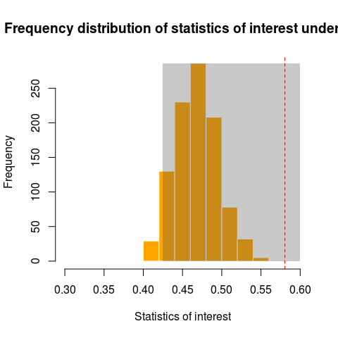

Frequency distribution of the niche overlap index of aphids in 1000 simulations of the null hypothesis that the associations of aphids and plant species are independent. Zeroes (plants without the record of each species) were kept fixed. The red line shows the observed value of niche overlap.

```r
> dplot(pielou.r1, svalue = pielou.si(pielou), pside="Lesser",
+       main = "Frequency distribution of statistics of interest under H0",
+       xlab = "Statistics of interest", xlim=c(0.3,0.6))
```

### Decision: do we reject the null hypothesis?

The observed value of our statistic of interest is within the acceptance region. Applying our significance criterion:

```r
> sum(pielou.r1 <= pielou.si(pielou))/1000 < 0.05
[1] FALSE
```

**Conclusion:** we do not reject the null hypothesis. (p > 0,05).

[^1]: Statistics.com LCC. 2009. Resampling Stats Add-in for Excel User’s Guide. http://www.resample.com/content/software/excel/userguide/RSXLHelp.pdf
[^2]: There are simpler and faster ways to do this, but this one replicates the logic of drawing from an urn in *Rsampling Stats*